# Covid-19 Analysis

$$INTRODUCTION$$
The most crucial thing in analyzing a pandemic is to ensure that all the factors that are responsible for the outbreak are well considered. Missing out on any of such factors, however trivial it might seem, will not give an accurate analysis. What makes this type of analysis challenging is the number of factors that keep varying across different countries. Considering the common and important ones which can be relied on for accurate analysis is what we get to learn from this project.
Sometimes drilling down to root cause for analysis can turn out to be a futile effort. But identifying the right factors to do right analysis is equally important for analysing this kind of varying data. To name a few factors in the dataset that play a key role to help us analyse the outbreak are total cases, total deaths, total tests, population, recommendation delay, lockdown delay, health care index and many more. Data analysis of this dataset is needed to identify the direct and indirect relation between these variables. Using the existing statistics to identify such correlation can help countries in future to mitigate the widespread in case of such recurring pandemic. This has been the main interest behind analysing the dataset.
Analysing data for the COVID-19 pandemic is very important. There are few countries who were successful in controlling and few who were not. Despite a good health care index, some countries still failed miserably in controlling the widespread. Some, despite having more population, had fewer cases as compared to other countries with a smaller population size but a lot of positive corona infected cases. At this point it becomes difficult to consider which factors can be assumed to help countries from preventing the spread of this virus. This analysis will tell us that it is not just one or two factors that are essential but a combination of multiple factors that needs to be addressed and focused up on equally, which will help us to control the widespread and also on how to put an end to this pandemic or any such pandemic in future.

$$Data$$
Analysis of such data is challenging. As expected, there was no such particular data that had covered all the variables which play an essential role to help in analysing data for COVID-19. In this project multiple datasets were merged into one to represent a meaningful meaningful analysis that helps to make an accurate analysis.

Our dataset consists of 198 countries with 26 variables. There are few variables which were used to create data sets for accurate analysis.

[output not shown]

$$Preloading Libraries$$

```r
library(tidyverse)
require(knitr)
require(lattice)
library(dplyr)
require(ggplot2)
install.packages("corrplot")
require(corrplot)
```

$$Loading Data$$

```r
COVID <- read_csv("COVID19.csv")
```

## Checking Data for NA values and analyzing the all the Variables

```r
COVID  %>% is.na() %>% colSums()
```

```
                 Country               TotalCases              TotalDeaths           TotalRecovered              ActiveCases
                       0                        0                        0                        0                        0
         SeriousCritical           Population2020   TotalCases_per_million       Deaths_per_million               TotalTests
                       0                        0                        0                        0                        0
 Total tests_per_million Net_change_in_population    Yearly_change_percent                  Density            Land Area_km2
                       0                        0                        0                        0                        0
            Migrants_net           Fertility_rate               Median_age Urban_Population_percent      World_share_percent
                       0                        0                        0                        0                        0
       First_corona_case      Recommendation_date            Lockdown_date    Recomemendation_delay           Lockdown_delay
                       0                        0                       19                        0                       19
       Health_care_index
                       0
```

## Creating a numeric table and performing corelation

```r
nums <- unlist(lapply(COVID, is.numeric))
numeric <- COVID[ , nums]

numeric.rcorr = rcorr(as.matrix(numeric))
numeric.rcorr
```

[figure not shown]

```r
numeric.cor = cor(numeric, method = c("spearman"))
corrplot(numeric.cor)
```

$$Discriptive Analysis$$
Knowing how ADVERSELY is the world affected due to the new Pendamic COVID-19

```r
sum(numeric$Population2020)
```

```
[1] 7631471065
```

```r
sum(numeric$TotalCases)
```

```
[1] 2990756
```

```r
sum(numeric$TotalDeaths)
```

```
[1] 206884
```

```r
sum(numeric$TotalRecovered)
```

```
[1] 875643
```

```r
sum(numeric$ActiveCases)
```

```
[1] 1907885
```

```r
mean(numeric$Recomemendation_delay)
```

```
[1] 16.09596
```

```r
range(numeric$Median_age)
```

```
[1] 15 52
```

Now as we know our data well, its time to explore some insites

$$Exploratory Analysis$$

1. Which are the top 10 countries affected by COVID-19?

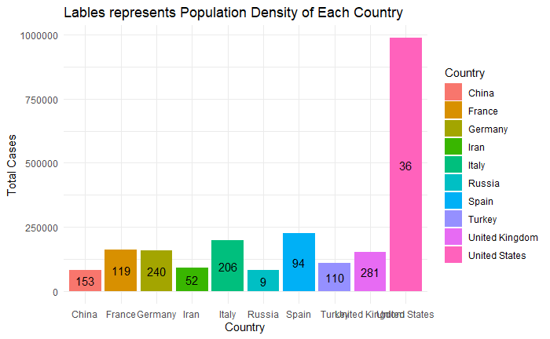

```r
few<-COVID%>% select(Country,TotalCases,ActiveCases,Population2020,Density,TotalCases_per_million,Recomemendation_delay,World_share_percent,Lockdown_delay) %>% arrange(desc(COVID$`TotalCases`)) %>% head(10)

ggplot(few, aes(x=Country, y=TotalCases, fill=Country)) +
geom_bar(stat="identity")+theme_minimal() + geom_text(aes(label = paste0(round(Density))), position = position_stack(vjust = 0.5))+labs(title='Lables represents Population Density of Each Country', x = "Country", y = "Total Cases")
```

```r
NA
NA
```

```r
df<-COVID%>% select(Country,TotalCases,ActiveCases,Population2020,Recomemendation_delay,Health_care_index,Lockdown_delay) %>% arrange(desc(COVID$`TotalCases`)) %>% head(10)

df
```

| Country | TotalCases | ActiveCases | Population2020 | Recomemendation_delay | Health_care_index | Lockdown_delay |
| --- | --- | --- | --- | --- | --- | --- |
| United States | 987160 | 812966 | 331002651 | 56 | 69.27 | 72 |
| Spain | 226629 | 85712 | 46754778 | 38 | 78.88 | 43 |
| Italy | 197675 | 106103 | 60461826 | 40 | 66.59 | 40 |
| France | 162100 | 94341 | 65273511 | 44 | 79.99 | 53 |
| Germany | 157770 | 39794 | 83783942 | 51 | 73.32 | 37 |
| United Kingdom | 152840 | 131764 | 67886011 | 51 | 74.46 | 52 |
| Turkey | 110130 | 78185 | 84339067 | 44 | 69.80 | 44 |
| Iran | 90481 | 15114 | 83992949 | 15 | 51.70 | 15 |
| China | 82827 | 801 | 1408526449 | 67 | 64.48 | 67 |
| Russia | 80949 | 73435 | 145934462 | 34 | 57.59 | 33 |

-> These are the top 10 most severely affected countries.

2.How does population affect Total Number of Positive COVID-19 Cases?

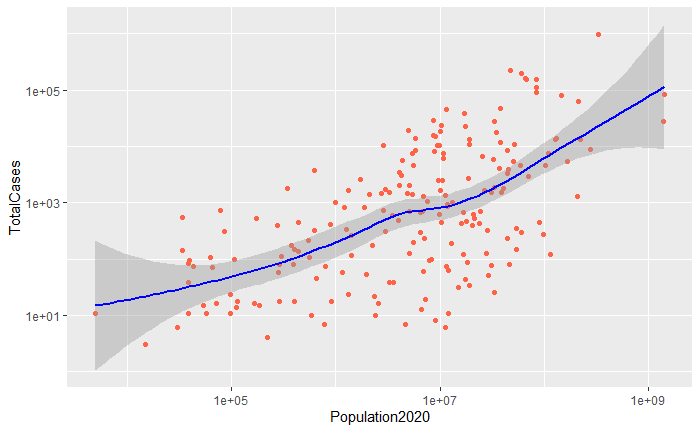

```r
 ggplot(data = COVID, mapping = aes(x = Population2020, y = TotalCases)) +
    geom_point(alpha = 3, color = "blue") +
    geom_jitter(alpha = 9, color = "tomato") + scale_x_log10() + scale_y_log10() + geom_smooth(color ="blue")
```

3. Are there any countries that have not yet Imposed Lockdown? Which are they and How are they affected?

```r
nolock<-
  COVID %>%
  filter(is.na(Lockdown_delay))
```

```r
nolock %>% select(Country,Recomemendation_delay,TotalCases,ActiveCases,Median_age,TotalDeaths,Population2020)
```

| Country | Recomemendation_delay | TotalCases | ActiveCases | Median_age | TotalDeaths | Population2020 |
| --- | --- | --- | --- | --- | --- | --- |
| Belarus | 53 | 10463 | 8696 | 40 | 72 | 9449323 |
| Cameroon | 12 | 1621 | 779 | 19 | 56 | 26545863 |
| Channel Islands | 15 | 525 | 158 | 43 | 35 | 173863 |
| Equatorial Guinea | 9 | 258 | 249 | 22 | 1 | 1402985 |
| Hong Kong | 17 | 1038 | 262 | 45 | 4 | 7496981 |
| Iceland | 16 | 1792 | 174 | 37 | 10 | 341243 |
| Latvia | 11 | 812 | 533 | 44 | 12 | 1886198 |
| Macao | 11 | 45 | 14 | 39 | 0 | 649335 |
| Maldives | 11 | 214 | 197 | 30 | 0 | 540544 |
| Réunion | 18 | 417 | 117 | 36 | 0 | 895312 |

[output cut: 9 more lines]

->There are 19 Countries that did not implement Lockdown. We get a vague observation that there are countries with less cases and also more cases which didn’t implement lockdown. This points out to the fact that we need to explore other variables that might be responsible for the outbreak.

4. Is there any relation between Total cases per million and density?

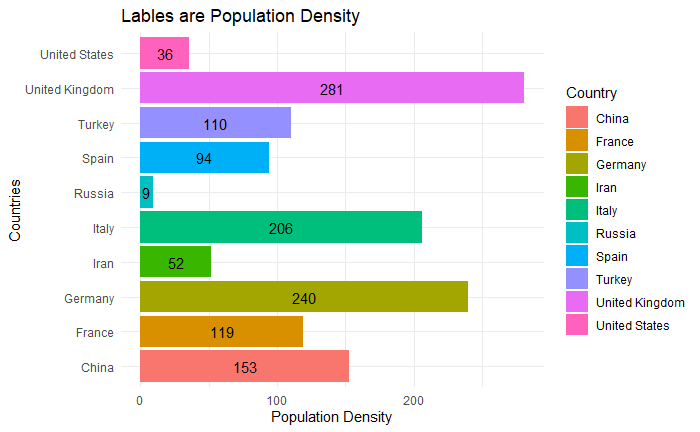

```r
ggplot(few, aes(x=Density, y=Country, fill=Country)) +
geom_bar(stat="identity")+theme_minimal() + geom_text(aes(label = paste0(round(Density))), position = position_stack(vjust = 0.5))+labs(title='Lables are Population Density', x = "Population Density", y = "Countries")
```

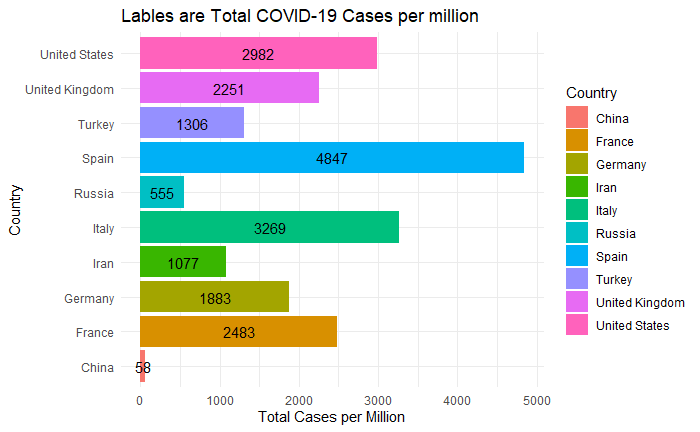

```r
ggplot(few, aes(x=TotalCases_per_million, y=Country, fill=Country)) +
geom_bar(stat="identity")+theme_minimal() + geom_text(aes(label = paste0(round(TotalCases_per_million))), position = position_stack(vjust = 0.5))+labs(title='Lables are Total COVID-19 Cases per million', x = "Total Cases per Million", y = "Country")
```

->We can see that from the graph, there is no relation between density and total cases per million. Some countries with higher population density but have lesser total cases per million and vice versa. This leads us to analyse the delay in actions against the COVID-19 outbreak which has increased the total cases in each country.

5.Are there any outliers in the Impact of COVID-19 Cases and Lockdown Delay?

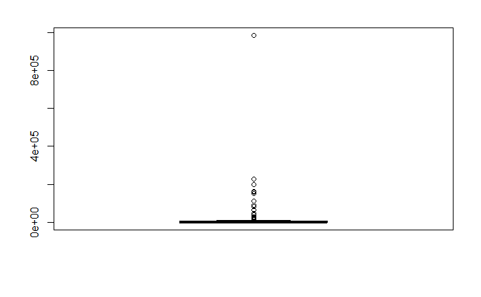

```r
boxplot(numeric$TotalCases)
```

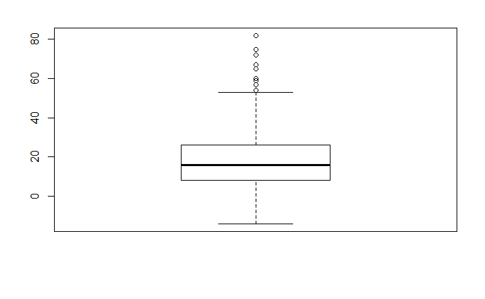

```r
boxplot(numeric$Lockdown_delay)
```

6.How were the countries based on delay in lockdown affected by COVID-19? Is there any difference in impact?

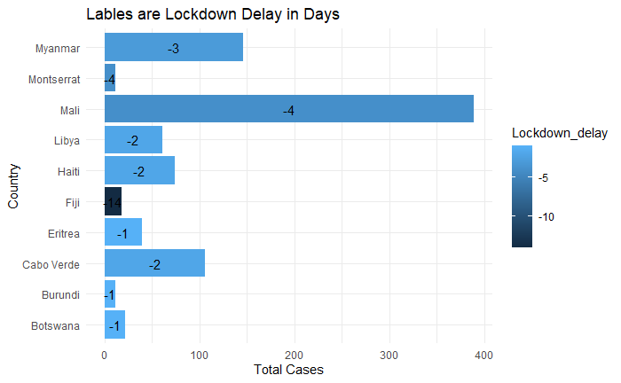

```r
nld <-COVID%>% select(Country,TotalCases,ActiveCases,Population2020,Recomemendation_delay,Health_care_index,Lockdown_delay) %>%   arrange(COVID$`Lockdown_delay`) %>% head(10)

ld<-COVID%>% select(Country,TotalCases,ActiveCases,Population2020,Recomemendation_delay,Health_care_index,Lockdown_delay) %>%   arrange(desc(COVID$`Lockdown_delay`)) %>% head(10)

ggplot(nld, aes(x=TotalCases , y=Country, fill=Lockdown_delay)) +
geom_bar(stat="identity")+theme_minimal() + geom_text(aes(label = paste0(round(Lockdown_delay))), position = position_stack(vjust = 0.5))+labs(title='Lables are Lockdown Delay in Days', x = "Total Cases", y = "Country")
```

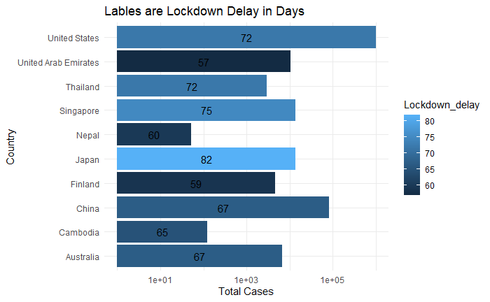

```r
ggplot(ld, aes(x=TotalCases, y=Country, fill=Lockdown_delay)) +
geom_bar(stat="identity")+theme_minimal() + geom_text(aes(label = paste0(round(Lockdown_delay))), position = position_stack(vjust = 0.5)) + scale_x_log10()+labs(title='Lables are Lockdown Delay in Days', x = "Total Cases", y = "Country")
```

```r
NA
NA
NA
```

7. Does Total Cases has any Impact due to Delay in Recommending the citizen “ways to protect themselves”?

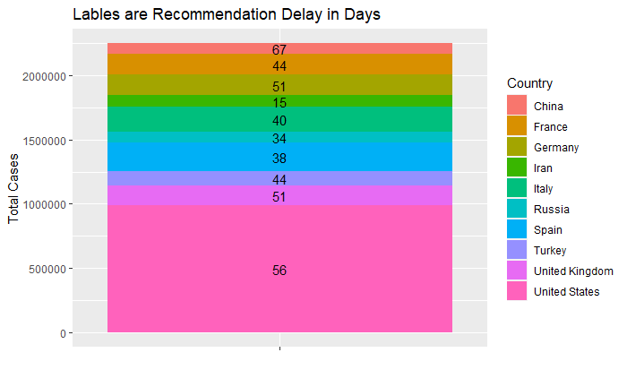

```r
bp<- ggplot(few, aes(x="", y=TotalCases, fill=Country))+
geom_bar(width = 1, stat = "identity") + geom_text(aes(label = paste0(round(Recomemendation_delay))), position = position_stack(vjust = 0.5)) + labs(title='Lables are Recommendation Delay in Days', x = "", y = "Total Cases")
bp
```

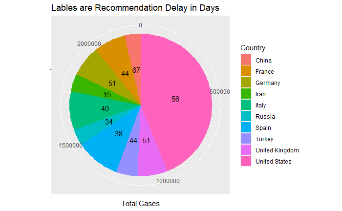

```r
pie <- bp + coord_polar("y",start=0)
pie
```

8.Does Health care Index of the countries affect their Total test taken and Recoveries

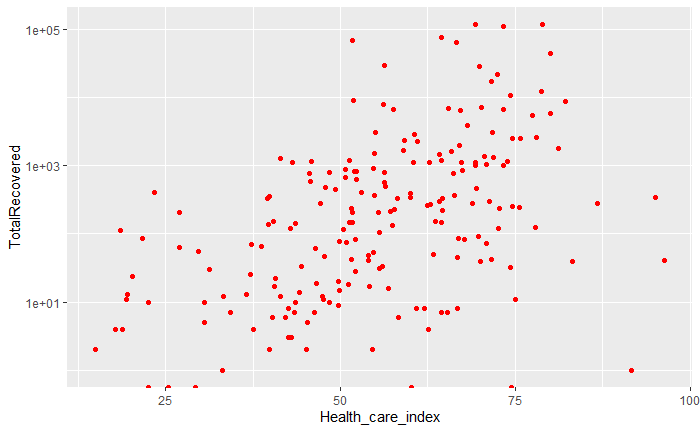

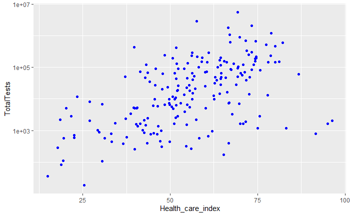

```r
m <- ggplot(data = numeric, mapping = aes(x = Health_care_index, y = TotalTests)) +
         geom_point(alpha = 4, color = "blue")

m + scale_y_log10()
```

```r
NA
```

-> Health care Index plays an important role for a country. Number of tests taken and total recoveries are higher in countries with higher Health care Index.

9.Does certain median age group of a country has any relation to total deaths?

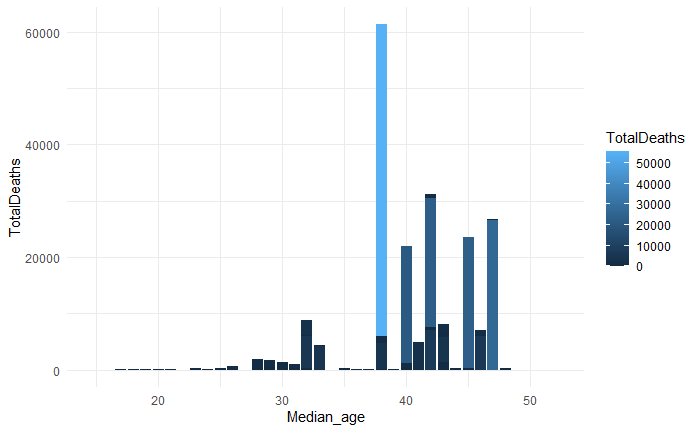

->It appears that the countries who are affected most by the COVID-19 have a median age group mostly between 37 to 47. This might also be a possibility that COVID-19 affects countries with a higher age group.